# AIRLINE PASSENGERS SATISFACTION

## Analysis of Leg room service and Class

```python
cat0 = data['Leg room service'] == 0
cat1 = data['Leg room service'] == 1
cat2 = data['Leg room service'] == 2
cat3 = data['Leg room service'] == 3
cat4 = data['Leg room service'] == 4
cat5 = data['Leg room service'] == 5
```

```python
sat = data['Class']
catscore0 = sat[cat0]
catscore1 = sat[cat1]
catscore2 = sat[cat2]
catscore3 = sat[cat3]
catscore4 = sat[cat4]
catscore5 = sat[cat5]
```

```python
freq0 = catscore0.value_counts()
freq1 = catscore1.value_counts()
freq2 = catscore2.value_counts()
freq3 = catscore3.value_counts()
freq4 = catscore4.value_counts()
freq5 = catscore5.value_counts()
plotdata = pd.DataFrame({0: freq0,1: freq1,2: freq2,3: freq3,4: freq4,5: freq5})
plotdata1=plotdata.div(plotdata.sum(axis=1),axis =0)*100
```

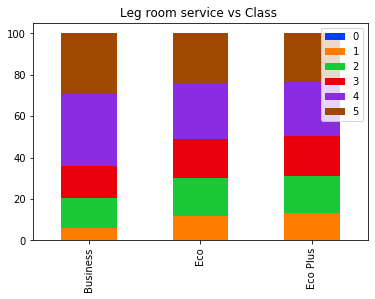

```python
plotdata1.plot(kind='bar',stacked = True)
plt.title('Leg room service vs Class ')
```

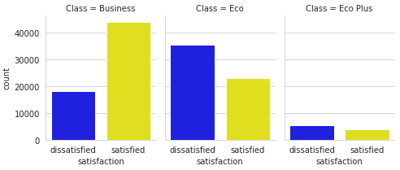

```python
import seaborn as sns
import matplotlib.pyplot as plt
sns.set_palette("bright")

with sns.axes_style(style='whitegrid'):
    g = sns.catplot("satisfaction", col="Class", col_wrap=3, data=data, kind="count", height=3.0, aspect=0.75, palette=['Blue', 'Yellow'])
```

### Box plot of Age plotted with respect to satisfaction

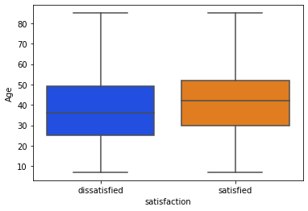

```python
sns.boxplot(x="satisfaction", y="Age", data=data)
```

### Bar plot of passengers class and inflight wifi service classified into dissatisfied and satisfied passengers

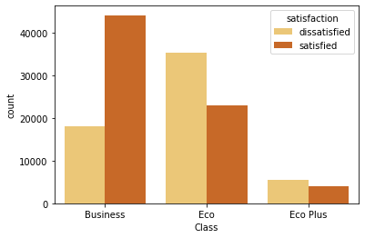

```python
sns.countplot(x = 'Class', hue = 'satisfaction', palette = "YlOrBr", data = data)
plt.show()
```

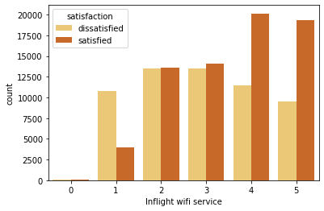

```python
sns.countplot(x = 'Inflight wifi service', hue = 'satisfaction', palette = "YlOrBr", data = data)
plt.show()
```

### Bar plot of passengers seat comfort and leg room service classified into dissatisfied and satisfied passengers

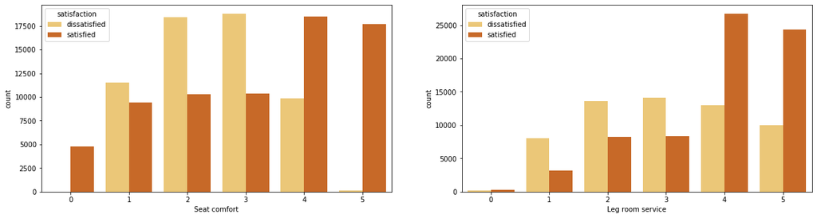

```python
f, ax = plt.subplots(1, 2, figsize = (20,5))
sns.countplot(x = 'Seat comfort', hue = 'satisfaction', palette = "YlOrBr", data = data,ax = ax[0])
sns.countplot(x = 'Leg room service', hue = 'satisfaction', palette = "YlOrBr", data = data, ax = ax[1])
plt.show()
```

## Analysis of Satisfaction and Checkin service

```python
cat0 = data['Checkin service'] == 0
cat1 = data['Checkin service'] == 1
cat2 = data['Checkin service'] == 2
cat3 = data['Checkin service'] == 3
cat4 = data['Checkin service'] == 4
cat5 = data['Checkin service'] == 5
```

```python
sat = data['satisfaction']
catscore0 = sat[cat0]
catscore1 = sat[cat1]
catscore2 = sat[cat2]
catscore3 = sat[cat3]
catscore4 = sat[cat4]
catscore5 = sat[cat5]
```

```python
freq0 = catscore0.value_counts()
freq1 = catscore1.value_counts()
freq2 = catscore2.value_counts()
freq3 = catscore3.value_counts()
freq4 = catscore4.value_counts()
freq5 = catscore5.value_counts()
plotdata = pd.DataFrame({0: freq0,1: freq1,2: freq2,3: freq3,4: freq4,5: freq5})
plotdata1=plotdata.div(plotdata.sum(axis=1),axis =0)*100
```

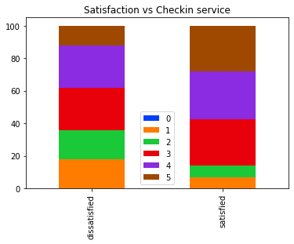

```python
plotdata1.plot(kind='bar',stacked = True)
plt.title('Satisfaction vs Checkin service')
```

## Analysis of Satisfaction and Food and drink

```python
cat0 = data['Food and drink'] == 0
cat1 = data['Food and drink'] == 1
cat2 = data['Food and drink'] == 2
cat3 = data['Food and drink'] == 3
cat4 = data['Food and drink'] == 4
cat5 = data['Food and drink'] == 5
```

```python
sat = data['satisfaction']
catscore0 = sat[cat0]
catscore1 = sat[cat1]
catscore2 = sat[cat2]
catscore3 = sat[cat3]
catscore4 = sat[cat4]
catscore5 = sat[cat5]
```

```python
freq0 = catscore0.value_counts()
freq1 = catscore1.value_counts()
freq2 = catscore2.value_counts()
freq3 = catscore3.value_counts()
freq4 = catscore4.value_counts()
freq5 = catscore5.value_counts()
plotdata = pd.DataFrame({0: freq0,1: freq1,2: freq2,3: freq3,4: freq4,5: freq5})
plotdata1=plotdata.div(plotdata.sum(axis=1),axis =0)*100
```

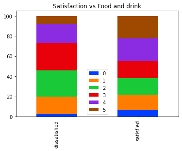

```python
plotdata1.plot(kind='bar',stacked = True)
plt.title('Satisfaction vs Food and drink')
```

## Analysis of Satisfaction and Seat comfort

```python
cat0 = data['Seat comfort'] == 0
cat1 = data['Seat comfort'] == 1
cat2 = data['Seat comfort'] == 2
cat3 = data['Seat comfort'] == 3
cat4 = data['Seat comfort'] == 4
cat5 = data['Seat comfort'] == 5
```

```python
sat = data['satisfaction']
catscore0 = sat[cat0]
catscore1 = sat[cat1]
catscore2 = sat[cat2]
catscore3 = sat[cat3]
catscore4 = sat[cat4]
catscore5 = sat[cat5]
```

```python
freq0 = catscore0.value_counts()
freq1 = catscore1.value_counts()
freq2 = catscore2.value_counts()
freq3 = catscore3.value_counts()
freq4 = catscore4.value_counts()
freq5 = catscore5.value_counts()
plotdata = pd.DataFrame({0: freq0,1: freq1,2: freq2,3: freq3,4: freq4,5: freq5})
plotdata1=plotdata.div(plotdata.sum(axis=1),axis =0)*100
```

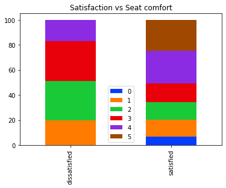

```python
plotdata1.plot(kind='bar',stacked = True)
plt.title('Satisfaction vs Seat comfort')
```

### Scarttered plot of Arrival delay against Departure delay

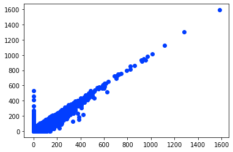

```python
plt.scatter(data['Arrival Delay in Minutes'], data['Departure Delay in Minutes'])
pass
```

### Scarttered Plot Matrix of Age, flight distance, departure and Arrival delay

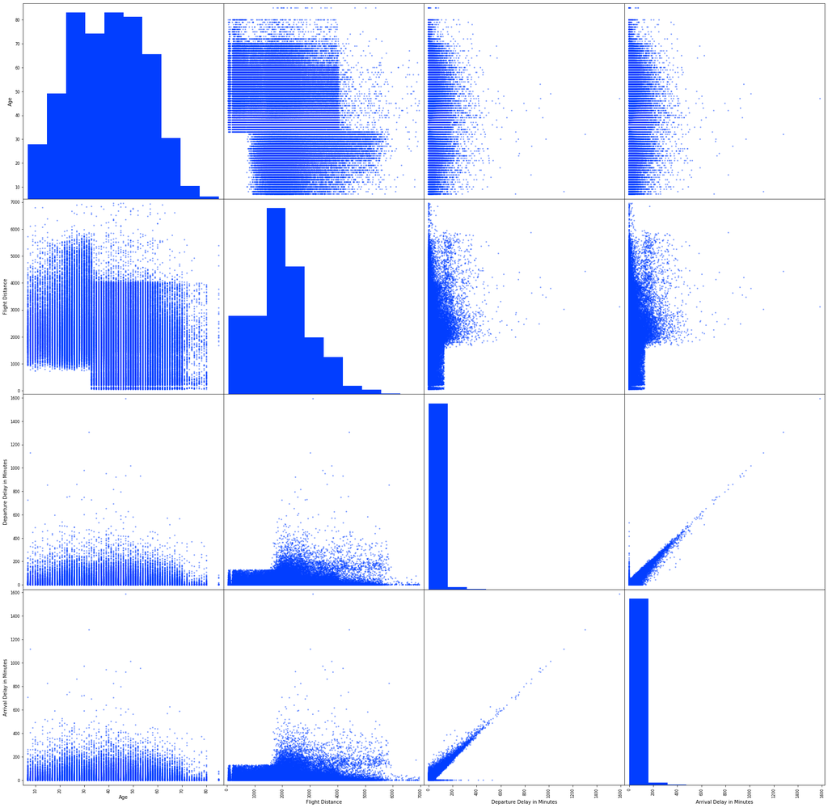

```python
pd.plotting.scatter_matrix(data,figsize=(30,30))
plt.show()
```

The above shows the Scarttered Plot Matrix of Age, flight distance, departure and Arrival delay against themselves.

# INFERENCES

## CORRELATION ANALYSIS

```python
corr_mat = data.corr()
corr_mat
```

|  | Age | Flight Distance | Departure Delay in Minutes | Arrival Delay in Minutes |
| --- | --- | --- | --- | --- |
| Age | 1.000000 | -0.249625 | -0.009041 | -0.011206 |
| Flight Distance | -0.249625 | 1.000000 | 0.112555 | 0.109733 |
| Departure Delay in Minutes | -0.009041 | 0.112555 | 1.000000 | 0.959382 |
| Arrival Delay in Minutes | -0.011206 | 0.109733 | 0.959382 | 1.000000 |

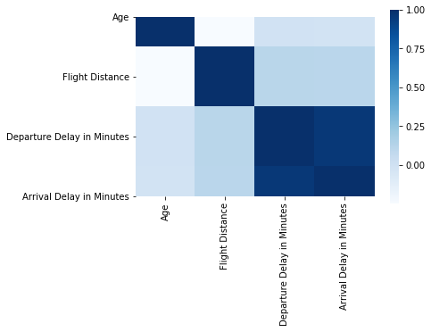

```python
sns.heatmap(corr_mat, square = True, cmap = 'Blues')
pass
```

### Interpretation

From the correlation table above, we can see that Age has a very weak negative correlation with Flight Distance, Departure delay and Arrival delay. Where, Flight distance has a very weak but positive correlation with Departure delay and a=Arrival delay. And Departure delay has a very strong and positive correlation with Arrival delay

### REGRESSION ANALYSIS

```python
from sklearn.linear_model import LinearRegression

#### inputting your data set(X and Y)
X = data['Arrival Delay in Minutes']
print("X: ", X)

Y = data['Departure Delay in Minutes']
print("Y: ", Y)


# arranging the data in numpy
x = np.array(X).reshape((-1,1))
y = np.array(Y)
print("here is your data in numpy!")
print(x)
print(y)
```

```
X:  0           0.0
1         305.0
2           0.0
3           0.0
4           0.0
          ...
129875      0.0
129876    172.0
129877    163.0
129878    205.0
129879    186.0
Name: Arrival Delay in Minutes, Length: 129880, dtype: float64
Y:  0           0
1         310
2           0
3           0
4           0
         ...
129875      0
129876    174
129877    155
129878    193
129879    185
Name: Departure Delay in Minutes, Length: 129880, dtype: int64
here is your data in numpy!
[[  0.]
 [305.]
 [  0.]
 ...
 [163.]
 [205.]
 [186.]]
[  0 310   0 ... 155 193 185]
```

```python
print("These are the estimatees of the parameters you will need to compute your regression analysis")
# fitting regression model
model = LinearRegression()
model.fit(x, y)
model = LinearRegression().fit(x, y)

# to find the coeficient of determination
r_sq = model.score(x, y)
print('coefficient of determination:', r_sq)

# to find the intercept
A = model.intercept_
print('intercept:', A)

# to find the slope
B = model.coef_
print('slope:', B)

##### Printing equation
print("Prediction Equation :")
print("Y", "=", A, "+", B, "x")
```

```
These are the estimatees of the parameters you will need to compute your regression analysis
coefficient of determination: 0.9204144999479059
intercept: 0.40907254388288017
slope: [0.95076092]
Prediction Equation :
Y = 0.40907254388288017 + [0.95076092] x
```

```python
model2 = sm.OLS(Y, X)
mod = model2.fit()
print(mod.summary())
```

```
                                     OLS Regression Results
===============================================================================================
Dep. Variable:     Departure Delay in Minutes   R-squared (uncentered):                   0.931
Model:                                    OLS   Adj. R-squared (uncentered):              0.931
Method:                         Least Squares   F-statistic:                          1.743e+06
Date:                        Sun, 10 Jul 2022   Prob (F-statistic):                        0.00
Time:                                02:07:44   Log-Likelihood:                     -4.9271e+05
No. Observations:                      129880   AIC:                                  9.854e+05
Df Residuals:                          129879   BIC:                                  9.854e+05
Df Model:                                   1
Covariance Type:                    nonrobust
============================================================================================
                               coef    std err          t      P>|t|      [0.025      0.975]
--------------------------------------------------------------------------------------------
Arrival Delay in Minutes     0.9544      0.001   1320.404      0.000       0.953       0.956
==============================================================================
Omnibus:                    88113.826   Durbin-Watson:                   1.991
Prob(Omnibus):                  0.000   Jarque-Bera (JB):         96847653.707
Skew:                           1.836   Prob(JB):                         0.00
Kurtosis:                     136.726   Cond. No.                         1.00
==============================================================================

Warnings:
[1] Standard Errors assume that the covariance matrix of the errors is correctly specified.
```

#### Interpretation

the above regression tables shows the probability value, the slope, intercept among others, and from the table, it can be decducted that there is significance relationship between arrial and departure time at 95% confidence interval, with its pvalue lesser than 0.05

### CHI-SQUARE ANALYSIS

```python
chisqt = pd.crosstab(data.Gender, data.satisfaction, margins = True)
print(chisqt)
```

```
satisfaction  dissatisfied  satisfied     All
Gender
Female               22971      42928   65899
Male                 35822      28159   63981
All                  58793      71087  129880
```

```python
value = np.array([chisqt.iloc[0][0:5].values, chisqt.iloc[1][0:5].values])
print(chi2_contingency(value)[0:3])
```

```
(5850.329227936873, 0.0, 2)
```

### Interpretation

From the chi2 analysis above, it is revealed that there is a significance relationship between the passengers gender and Satisfaction at 95% confidence interval, with the p-value (0.0) less than 0.05.

## **T-TEST**

```python
rp.ttest(group1 = data['Age'][data['Gender'] == 'Male'], group1_name = "Male", group2 = data['Age'][data['Gender'] == 'Female'], group2_name = "Female")
```

```
(   Variable         N       Mean         SD        SE  95% Conf.   Interval
 0      Male   63981.0  39.565996  15.096960  0.059685  39.449014  39.682978
 1    Female   65899.0  39.293935  15.139987  0.058977  39.178339  39.409530
 2  combined  129880.0  39.427957  15.119360  0.041953  39.345730  39.510184,
               Independent t-test      results
 0  Difference (Male - Female) =        0.2721
 1          Degrees of freedom =   129878.0000
 2                           t =        3.2422
 3       Two side test p value =        0.0012
 4      Difference < 0 p value =        0.9994
 5      Difference > 0 p value =        0.0006
 6                   Cohen's d =        0.0180
 7                   Hedge's g =        0.0180
 8               Glass's delta =        0.0180
 9                 Pearson's r =        0.0090)
```

### Interpretation

from the t-test result above, it can be concluded that there is significance differnece between the mean age of passengers genders with the t-test p-value lesser than 0.05. and the t-statistics of 3.2422

```python
summary, results = rp.ttest(group1 = data['Age'][data['Gender'] == 'Male'], group1_name = "Male",  group2 = data['Age'][data['Gender'] == 'Female'], group2_name = "Female")
print(summary)
```

```
   Variable         N       Mean         SD        SE  95% Conf.   Interval
0      Male   63981.0  39.565996  15.096960  0.059685  39.449014  39.682978
1    Female   65899.0  39.293935  15.139987  0.058977  39.178339  39.409530
2  combined  129880.0  39.427957  15.119360  0.041953  39.345730  39.510184
```

```python
print(results)
```

```
              Independent t-test      results
0  Difference (Male - Female) =        0.2721
1          Degrees of freedom =   129878.0000
2                           t =        3.2422
3       Two side test p value =        0.0012
4      Difference < 0 p value =        0.9994
5      Difference > 0 p value =        0.0006
6                   Cohen's d =        0.0180
7                   Hedge's g =        0.0180
8               Glass's delta =        0.0180
9                 Pearson's r =        0.0090
```

# Summary of Descriptive Analysis

More than half (54.7%) of the passengers are satisfied with the airline flight, where 45.3% are not. And female passengers seems to be slighty greater than male passenger with the percentage of 50.7% compared to male of 49.3%. Also, the customer type is sen to be dominated with loyal customers with their percentage as high as 81.7% compared to disloyal customers which has just 18.3%. More passengers seems to be travelling for business purpose than those travelling for personal purpose, wwth percentage ratio of 69.1 : 30.9 percent.

The average age of passengers is 39years, with the minimum and maximum age of 7 and 85 years respectively, and average flight distance of 1981.41.

## Conclusion

From the relationship test between the arrival delay and departure delay, the result shows there is statistically relationship between arrival and departure delay.

The chi-square test shows that is significance relationship between the passengers gender and Satisfaction at 95% confidence interval.

And lastly, it can be concluded from the t-test result that there is significance differnece between the mean age of passengers genders with the t-test p-value lesser than 0.05.